# 2YP Notebook

### METHODS

##### 1. Participants

316 (69% female) English speakers aged 17 to 33 were recruited from the experimental-subject pool at a large public university in the United States (M(age) = 20.5, SD(age) = 2.2). Participants completed three activities: two graph reading tasks followed by a drawing task. In some cases (order = linear-first), participants (n = 154) completed the first graph reading task with a linear model graph, followed by the task with the triangular graph. To control for any effects of graph order on performance, an additional (n= 162) subjects completed the activities with the graphs in reverse order. Each participant was randomly assigned to one of five conditions which determined what additional information (scaffold) they received while solving the first five problems on each graph reading task: no-scaffold (control), ‘what’ text, ‘how’-text, static-image, interactive-image. The runtime of the entire study ranged from 22 to 66 minutes (M = 40, SD = 8.54).

In addition, we ran 6 expert participants through two conditions, composed of research assistants with more than 20 hours of experience analyzing data with the triangular model graph.

##### 2. Group Totals

Participants were randomnly assigned to task order (LMFirst, TMFirst) and Scaffold Condition (none, what-text, how-text, static image, interactive image) conditions

| Condition | Task Order TMFirst | Task Order LMFirst | All |
| --- | --- | --- | --- |
| 0 | 32 | 29 | 61 |
| 1 | 28 | 31 | 59 |
| 2 | 36 | 30 | 66 |
| 3 | 32 | 30 | 62 |
| 4 | 34 | 34 | 68 |
| All | 162 | 154 | 316 |

### EXPLORATION

##### Longmire Hypothesis

IN LONGMIRE scenario, there was NO available answer for the LM interpretation of the first TM question.

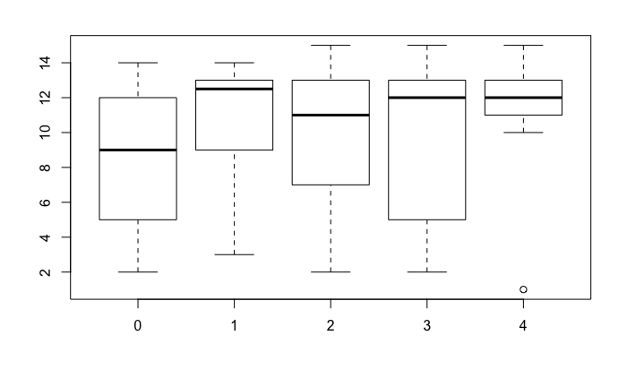

IN AXIS scenario, there was an available answer for the LM interpretation of the first TM question.

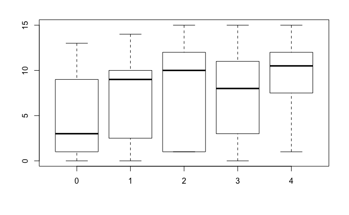

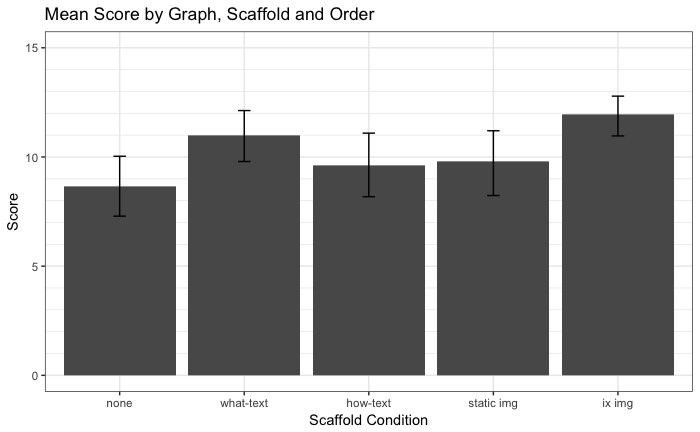

```
                 Df Sum Sq Mean Sq F value   Pr(>F)
linear_score      1  414.4   414.4  39.698  3.9e-09 ***
condition         4  247.1    61.8   5.917 0.000204 ***
order             1   14.5    14.5   1.386 0.241208
condition:order   4   20.6     5.1   0.493 0.740984
Residuals       135 1409.3    10.4
---
Signif. codes:  0 ‘***’ 0.001 ‘**’ 0.01 ‘*’ 0.05 ‘.’ 0.1 ‘ ’ 1
```

##### BAR CHART ALL SCORES

Visualize with bar chart

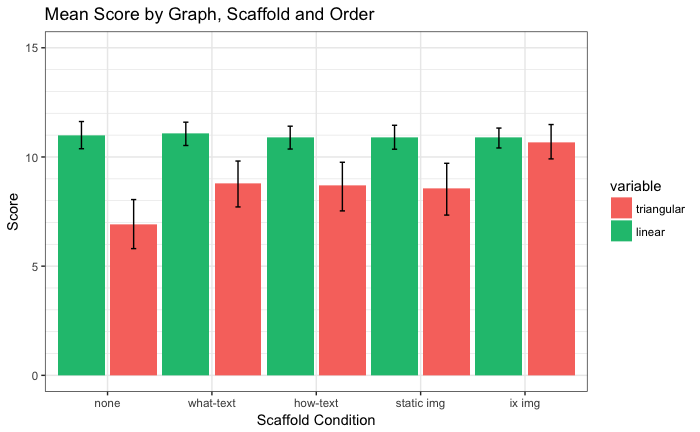

##### Relationship between GRAPH SCORE and DRAW TIME

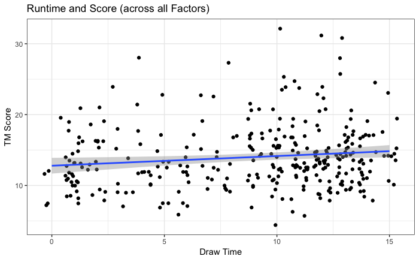

```
[1] 0.1330136
```

##### Relationship between graph time and graph score

> There is no correlation between response score and response latency (in graph tasks)

We might expect to see a positive, linear relationship between score and response time: it could take longer to come up with the correct answer. Conversely, if the question is `easy`, it should take less time (and be more likely to produce a correct answer), suggesting a negative linear relationship.

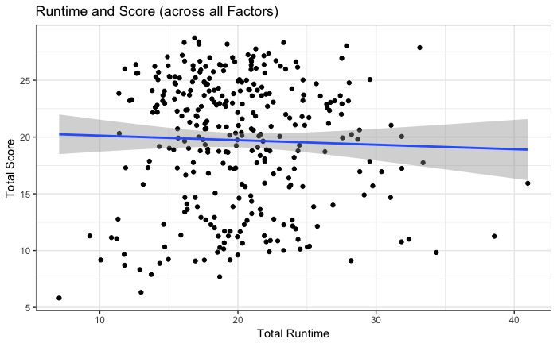

```
[1] -0.03526316
```

##### Relationship between graph score and drawing score

We might expect to see a positive, linear relationship between TM score and subsequent drawing score. How could students produce an accurate TM graph if they were not first able to answer questions with it?

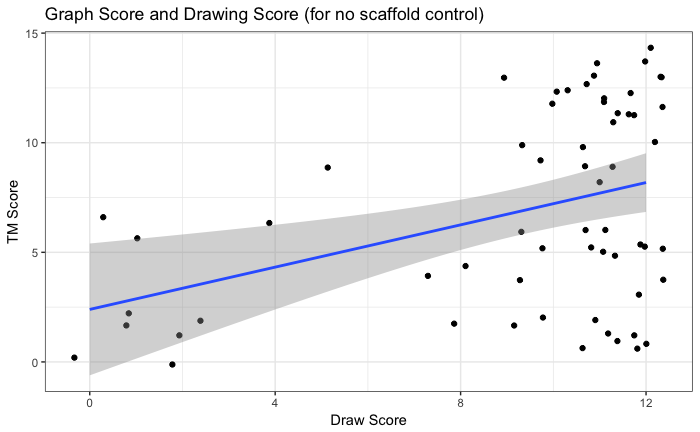

```
[1] 0.3856607
```

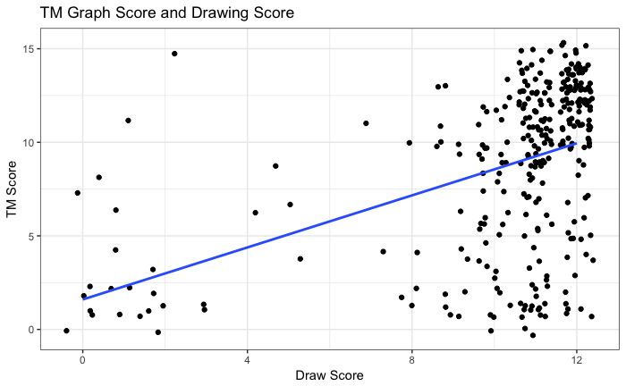

```
[1] 0.4369177
```

##### Relationship between graph score and drawing score by GRAPH INTERPRETATION

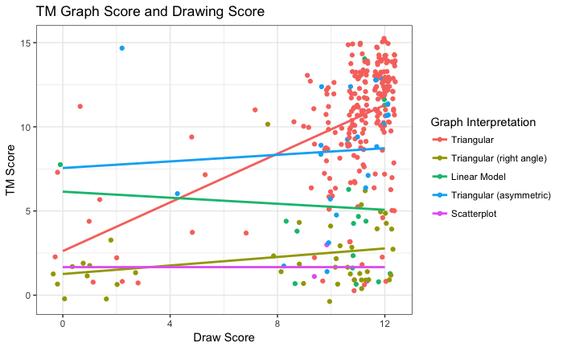

```
[1] 0.4369177
```

> What’s going on with the folks that score low on the TM model, and high on the drawing? What are their interpretations?

> display all

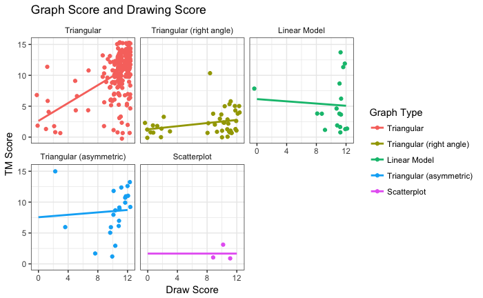

```
[1] 0.4369177
```

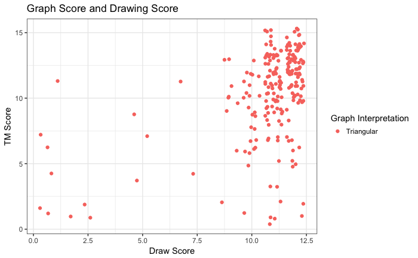

```
[1] 0.4369177
```

> DISPLAY TM INTERPRETATION

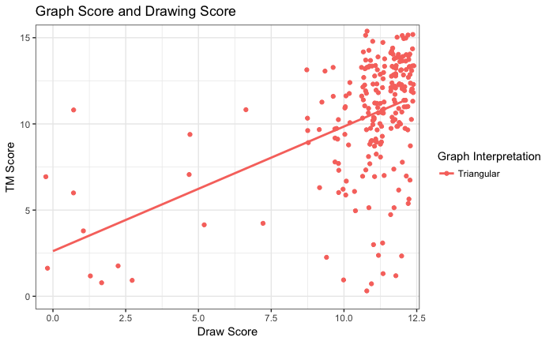

```
[1] 0.4732557
```

> DISPLAY RA INTERPRETATION

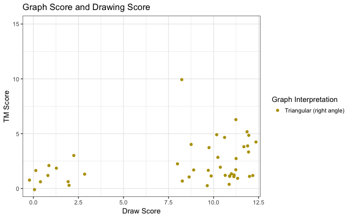

```
[1] 0.275282
```

> DISPLAY LM INTERPRETATION

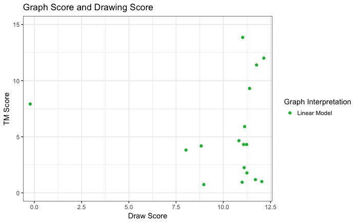

```
[1] -0.06156896
```

> DISPLAY ASY INTERPRETATION

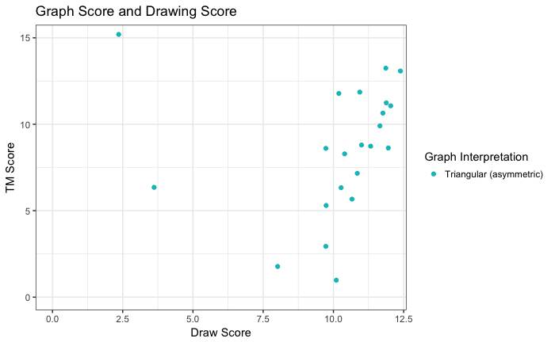

```
[1] 0.06697741
```

> DISPLAY SCATTERPLOT INTERPRETATION

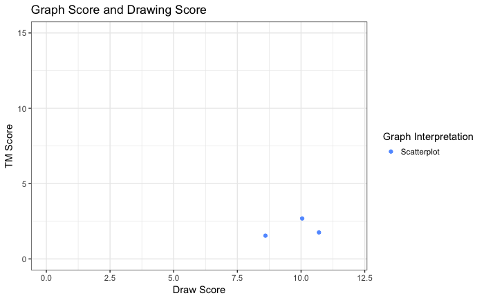

```
[1] 0
```

> DISPLAY BY CONDITION

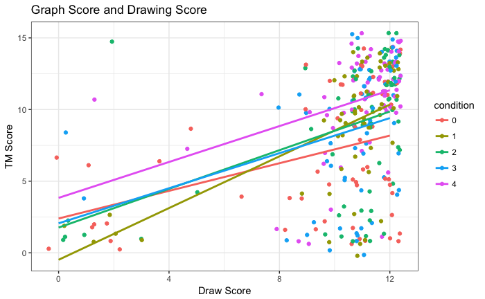

```
[1] 0.4369177
```

#### Are drawing time and score correlated?

No, there is no correlation between drawing time and drawing score

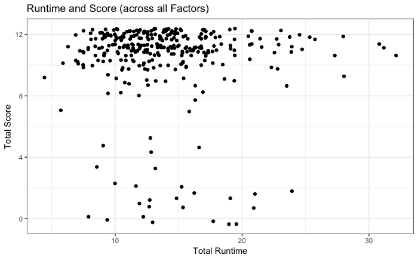

```
[1] -0.02337404
```

#### Assumptions: DO LM scores differ significantly by order or scaffold?

No, no significant difference are found in LM scores based on scaffold or task order. This confirms the assumption that LM is a conventional representation.

```
                 Df Sum Sq Mean Sq F value Pr(>F)
condition         4    1.3   0.336   0.073  0.990
order             1    2.3   2.322   0.501  0.480
condition:order   4    9.8   2.446   0.528  0.715
Residuals       306 1417.7   4.633
```

#### Hypothesis: DO TM scores differ significantly by scaffold, order or scenario?

```
                              Df Sum Sq Mean Sq F value   Pr(>F)
linear_score                   1    962   962.0  69.729 2.68e-15 ***
condition                      4    480   120.0   8.700 1.19e-06 ***
order                          1     59    58.8   4.259   0.0399 *
lm_scenarios                   1    496   496.0  35.952 5.90e-09 ***
condition:order                4    108    27.0   1.960   0.1007
condition:lm_scenarios         4     44    10.9   0.791   0.5317
order:lm_scenarios             1      3     3.2   0.232   0.6305
condition:order:lm_scenarios   4     18     4.5   0.326   0.8605
Residuals                    295   4070    13.8
---
Signif. codes:  0 ‘***’ 0.001 ‘**’ 0.01 ‘*’ 0.05 ‘.’ 0.1 ‘ ’ 1
```

### TABLES

##### Mean Response time and Score for Graphing Tasks

| CONDITION | Score LM mean | Score LM sd | Score TM mean | Score TM sd | Time LM mean | Time LM sd | Time TM mean | Time TM sd |
| --- | --- | --- | --- | --- | --- | --- | --- | --- |
| 0 | 0.732 | 0.155 | 0.460 | 0.301 | 8.616 | 2.121 | 11.152 | 3.551 |
| 1 | 0.738 | 0.146 | 0.588 | 0.285 | 9.840 | 2.967 | 11.616 | 3.628 |
| 2 | 0.726 | 0.142 | 0.580 | 0.314 | 9.099 | 2.295 | 10.925 | 3.043 |
| 3 | 0.728 | 0.147 | 0.571 | 0.305 | 9.098 | 2.590 | 10.754 | 3.448 |
| 4 | 0.726 | 0.126 | 0.712 | 0.227 | 9.376 | 2.571 | 9.913 | 2.589 |
| All | 0.730 | 0.142 | 0.585 | 0.297 | 9.203 | 2.534 | 10.846 | 3.284 |

##### Mean Response time and Score for Drawing Tasks

| CONDITION | Score mean | Score sd | Time mean | Time sd |
| --- | --- | --- | --- | --- |
| 0 | 0.779 | 0.300 | 13.31 | 3.567 |
| 1 | 0.859 | 0.233 | 15.13 | 5.307 |
| 2 | 0.856 | 0.264 | 14.08 | 4.680 |
| 3 | 0.886 | 0.177 | 13.77 | 4.553 |
| 4 | 0.911 | 0.149 | 13.71 | 4.534 |
| All | 0.859 | 0.233 | 13.99 | 4.569 |

##### Mean TM Score by Drawing Interpretation

```
                      TM Score             Draw Score
```

| INTERPRETATION | TM Score All | TM Score mean | TM Score sd | Draw Score mean | Draw Score sd |
| --- | --- | --- | --- | --- | --- |
| Triangular | 230.0 | 69.2 | 22.8 | 0.8953 | 0.18690 |
| Triangular (right angle) | 44.0 | 15.3 | 13.2 | 0.6837 | 0.35970 |
| Linear Model | 17.0 | 34.9 | 27.7 | 0.8480 | 0.23797 |
| Triangular (asymmetric) | 22.0 | 57.0 | 24.8 | 0.8447 | 0.21253 |
| Scatterplot | 3.0 | 11.1 | 7.7 | 0.8333 | 0.08333 |
| All | 316.0 | 58.5 | 29.7 | 0.8592 | 0.23296 |

##### Mean Drawing Interpretation X task order

[output not shown]

### SIMPLE: Compare Scaffolds to Control in TM SCORE

> Are scaffolds more effective than no scaffolds?

From the means, it appears that across all scaffold groups, scores were higher for scaffolds than the no-scaffold control. Students performed significantly better when they had access to a scaffold (M = 9.2, SD = 4.32) than when the did not (M = 6.9, SD = 4.51), t(88) = -3.64, p < .001, d = 0.53, a significant medium effect.

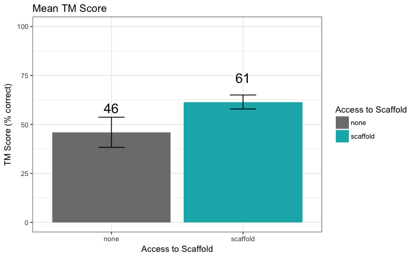

> Is this difference significant?

Students performed significantly better when they had access to a scaffold (M = 9.2, SD = 4.32) than when the did not (M = 6.9, SD = 4.51), t(88) = -3.64, p < .001, d = 0.53, a significant medium effect.

```
 Descriptive statistics by group
group: none
   vars  n mean   sd median trimmed  mad min max range skew kurtosis   se
X1    1 61  6.9 4.51      6    6.86 5.93   0  14    14 0.07    -1.47 0.58
---------------------------------------------------------------------------------------------
group: scaffold
   vars   n mean   sd median trimmed  mad min max range  skew kurtosis   se
X1    1 255 9.22 4.33     10     9.6 4.45   0  15    15 -0.75    -0.68 0.27

    Welch Two Sample t-test

data:  triangular_score by scaffolded
t = -3.6352, df = 88.346, p-value = 0.0004662
alternative hypothesis: true difference in means is not equal to 0
95 percent confidence interval:
 -3.585093 -1.050844
sample estimates:
    mean in group none mean in group scaffold
              6.901639               9.219608


Cohen's d

d estimate: -0.5313728 (medium)
95 percent confidence interval:
       inf        sup
-0.8148757 -0.2478699
```

> Does ORDER function as a scaffold for the TM (only for the control condition? NO

```
 Descriptive statistics by group
group: TMFirst
   vars  n mean   sd median trimmed  mad min max range skew kurtosis   se
X1    1 32 6.97 4.29      6    6.92 5.19   0  14    14 0.15    -1.34 0.76
---------------------------------------------------------------------------------------------
group: LMFirst
   vars  n mean   sd median trimmed  mad min max range skew kurtosis   se
X1    1 29 6.83 4.81      6     6.8 7.41   0  14    14 0.02     -1.7 0.89

    Welch Two Sample t-test

data:  triangular_score by order
t = 0.12044, df = 56.435, p-value = 0.9046
alternative hypothesis: true difference in means is not equal to 0
95 percent confidence interval:
 -2.206396  2.488724
sample estimates:
mean in group TMFirst mean in group LMFirst
             6.968750              6.827586


Cohen's d

d estimate: 0.03105478 (negligible)
95 percent confidence interval:
       inf        sup
-0.4819993  0.5441088
```

> Does ORDER function as a scaffold for the TM (only for the control condition? NO

```
 Descriptive statistics by group
group: TMFirst
   vars  n mean   sd median trimmed  mad min max range skew kurtosis   se
X1    1 32 6.97 4.29      6    6.92 5.19   0  14    14 0.15    -1.34 0.76
---------------------------------------------------------------------------------------------
group: LMFirst
   vars  n mean   sd median trimmed  mad min max range skew kurtosis   se
X1    1 29 6.83 4.81      6     6.8 7.41   0  14    14 0.02     -1.7 0.89

    Welch Two Sample t-test

data:  triangular_score by order
t = 0.12044, df = 56.435, p-value = 0.9046
alternative hypothesis: true difference in means is not equal to 0
95 percent confidence interval:
 -2.206396  2.488724
sample estimates:
mean in group TMFirst mean in group LMFirst
             6.968750              6.827586


Cohen's d

d estimate: 0.03105478 (negligible)
95 percent confidence interval:
       inf        sup
-0.4819993  0.5441088
```

### Compare Scaffolds to Control in TM TIME

> Are scaffolds more effective than no scaffolds?

No signfificant differences in time

[figure not shown]

> Is this difference significant?

Students with access to scaffolds did not spend significantly more or less time on the TM task than those in the control group.

```
 Descriptive statistics by group
group: none
   vars  n  mean   sd median trimmed  mad  min   max range skew kurtosis   se
X1    1 61 11.15 3.55  11.42   11.11 2.89 3.14 19.31 16.17 0.04     -0.2 0.45
---------------------------------------------------------------------------------------------
group: scaffold
   vars   n  mean   sd median trimmed  mad  min   max range skew kurtosis  se
X1    1 255 10.77 3.22  10.23   10.45 2.56 4.58 26.82 22.24 1.23     2.64 0.2

    Welch Two Sample t-test

data:  TM_T_M by scaffolded
t = 0.76123, df = 85.142, p-value = 0.4486
alternative hypothesis: true difference in means is not equal to 0
95 percent confidence interval:
 -0.610293  1.367547
sample estimates:
    mean in group none mean in group scaffold
              11.15180               10.77318


Cohen's d

d estimate: 0.1152316 (negligible)
95 percent confidence interval:
       inf        sup
-0.1653494  0.3958126
```

### Compare Scaffolds to Control in DIFF SCORE

> Are scaffolds more effective than no scaffolds?

If we account for the student’s performance on the LM graph by considering the difference in performance between the LM and TM graphs, we see that the difference in performance was significantly smaller when they had access to a scaffold (M = -1.73, SD = 3.88) than when the did not (M = -4.08, SD = 4.51), t(82) = -3.76, p < .001, d = 0.59, a significant medium effect.

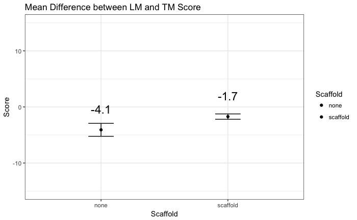

> Is this difference significant?

The difference in performance between the LM and TM graphs was significantly smaller when they had access to a scaffold (M = -1.73, SD = 3.88) than when the did not (M = -4.08, SD = 4.51), t(82) = -3.76, p < .001, d = 0.59, a significant medium effect.

```
 Descriptive statistics by group
group: none
   vars  n  mean   sd median trimmed  mad min max range skew kurtosis   se
X1    1 61 -4.08 4.51     -4   -4.12 5.93 -13   5    18 0.11    -1.04 0.58
---------------------------------------------------------------------------------------------
group: scaffold
   vars   n  mean   sd median trimmed  mad min max range  skew kurtosis   se
X1    1 255 -1.72 3.88     -1    -1.4 2.97 -12   5    17 -0.71    -0.17 0.24

    Welch Two Sample t-test

data:  score_diff by scaffolded
t = -3.7671, df = 82.546, p-value = 0.0003087
alternative hypothesis: true difference in means is not equal to 0
95 percent confidence interval:
 -3.606762 -1.114035
sample estimates:
    mean in group none mean in group scaffold
             -4.081967              -1.721569


Cohen's d

d estimate: -0.588589 (medium)
95 percent confidence interval:
       inf        sup
-0.8727834 -0.3043947
```

### SIMPLE: TM Score by Scaffold Group

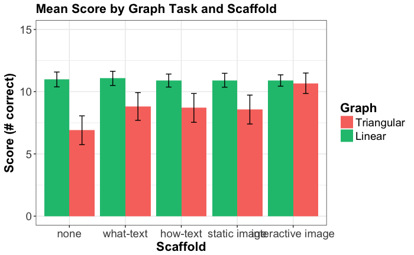

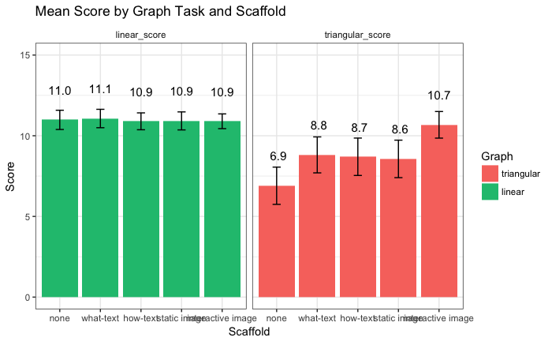

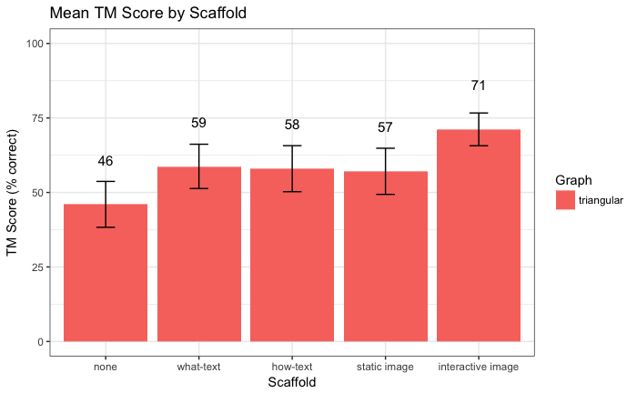

```
Call:
aov(formula = value ~ condition, data = t_scores)

Residuals:
   Min     1Q Median     3Q    Max
-9.677 -2.902  1.186  3.324  7.098

Coefficients:
            Estimate Std. Error t value Pr(>|t|)
(Intercept)  8.73063    0.24277  35.963  < 2e-16 ***
condition1  -1.82899    0.49156  -3.721 0.000236 ***
condition2   0.08293    0.49782   0.167 0.867806
condition3  -0.03366    0.47727  -0.071 0.943818
condition4  -0.16611    0.48855  -0.340 0.734075
---
Signif. codes:  0 ‘***’ 0.001 ‘**’ 0.01 ‘*’ 0.05 ‘.’ 0.1 ‘ ’ 1

Residual standard error: 4.31 on 311 degrees of freedom
Multiple R-squared:  0.07423,   Adjusted R-squared:  0.06232
F-statistic: 6.234 on 4 and 311 DF,  p-value: 7.754e-05

  Tukey multiple comparisons of means
    95% family-wise confidence level

Fit: aov(formula = value ~ condition, data = t_scores)

$condition
          diff         lwr      upr     p adj
1-0  1.9119200 -0.24736164 4.071202 0.1102152
2-0  1.7953304 -0.30493691 3.895598 0.1335241
3-0  1.6628768 -0.46968381 3.795437 0.2060796
4-0  3.7748312  1.68945189 5.860211 0.0000111
2-1 -0.1165896 -2.23527574 2.002096 0.9998828
3-1 -0.2490432 -2.39974610 1.901660 0.9977841
4-1  1.8629113 -0.24101728 3.966840 0.1102141
3-2 -0.1324536 -2.22390007 1.958993 0.9997950
4-2  1.9795009 -0.06381523 4.022817 0.0627214
4-3  2.1119545  0.03545911 4.188450 0.0440186
```

### DV: GRAPH SCORE

#### Construct a mixed ANOVA

```
Converting "subject" to factor for ANOVA.Data is unbalanced (unequal N per group). Make sure you specified a well-considered value for the type argument to ezANOVA().
```

|  | Effect | DFn | DFd | F | p | p<.05 | ges |
| --- | --- | --- | --- | --- | --- | --- | --- |
| 2 | condition | 4 | 296 | 4.24372694 | 2.351329e-03 | * | 3.740306e-02 |
| 3 | order | 1 | 296 | 0.73428345 | 3.921915e-01 |  | 1.677991e-03 |
| 4 | lm_scenarios | 1 | 296 | 22.25253533 | 3.689436e-06 | * | 4.846832e-02 |
| 9 | variable | 1 | 296 | 96.71109382 | 6.226124e-20 | * | 9.530930e-02 |
| 5 | condition:order | 4 | 296 | 0.68261709 | 6.044789e-01 |  | 6.211356e-03 |
| 6 | condition:lm_scenarios | 4 | 296 | 1.27789219 | 2.786863e-01 |  | 1.156531e-02 |
| 7 | order:lm_scenarios | 1 | 296 | 0.04326807 | 8.353644e-01 |  | 9.903297e-05 |
| 10 | condition:variable | 4 | 296 | 10.03978618 | 1.241419e-07 | * | 4.191296e-02 |
| 11 | order:variable | 1 | 296 | 3.42950549 | 6.503691e-02 |  | 3.721953e-03 |
| 12 | lm_scenarios:variable | 1 | 296 | 34.34297121 | 1.230461e-08 | * | 3.606168e-02 |

[output cut: 5 more lines]

```
      Length Class      Mode
ANOVA 7      data.frame list
```

[output not shown]

MIXED EFFECTS ANOVA ON SCORE  
Main effect of Scaffold F(4,297) = 4.24, p < .05  
Main effect of Scenario F(1,297) = 22.25, p < .001  
Main effect of Graph F(1,297) = 96.67, p < .001  
Interaction of Scaffold and Graph F(4,297) = 10.03, p <.001  
Interaction of Graph and Scenario F(1,297) = 34.34, p <.001

#### Main Effect: GRAPH

LM Model scores were significantly higher than TM scores.

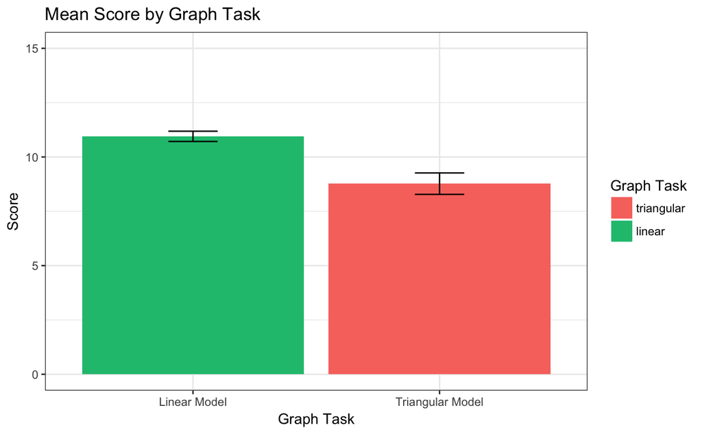

#### Main Effect of SCAFFOLD

Only condition #4: interactive graph, yielded significantly better performance than the control

#### Main Effect of SCENARIO

Scores were significantly lower in the axis scenario than the longmire scenario.

#### Interaction of GRAPH & SCAFFOLD

There was a significant interaction between graph-type and the scaffold condition,

#### Interaction of GRAPH & SCENARIO

There was a significant interaction between graph-type and scenario

[output not shown]

#### (almost) Interaction of GRAPH & ORDER

```
 Descriptive statistics by group
group: TMFirst
   vars   n mean   sd median trimmed  mad min max range  skew kurtosis   se
X1    1 162  8.4 4.51     10    8.61 4.45   0  15    15 -0.43     -1.2 0.35
---------------------------------------------------------------------------------------------------------
group: LMFirst
   vars   n mean   sd median trimmed  mad min max range  skew kurtosis   se
X1    1 154 9.16 4.37   10.5    9.53 3.71   0  15    15 -0.72    -0.74 0.35

    Welch Two Sample t-test

data:  triangular_score by order
t = -1.5238, df = 313.87, p-value = 0.1286
alternative hypothesis: true difference in means is not equal to 0
95 percent confidence interval:
 -1.743836  0.221630
sample estimates:
mean in group TMFirst mean in group LMFirst
             8.401235              9.162338


Cohen's d

d estimate: -0.1713671 (negligible)
95 percent confidence interval:
        inf         sup
-0.39321033  0.05047603
```

#### Interaction of GRAPH & SCAFFOLD & ORDER

The three-way interaction of graph-type, scaffold condition and graph-order approached significance at F(4,297) = 2.03, p = 0.09

### DV: RESPONSE TIME

#### Main effect of GRAPH

`Main Effect: Graph Type`

#### Interaction of GRAPH and SCENARIO

`IXN Graph Type & Order & Scenario` The three-way interaction of graph-type, scaffold condition and graph-order approached significance at F(4,297) = 2.23, p = 0.06.

### DV: DRAWING SCORE

##### Construct a mixed effects ANOVA on DRAW SCORE

```
                              Df Sum Sq Mean Sq F value Pr(>F)
condition                      4   89.1   22.28   3.001 0.0188 *
order                          1    0.8    0.81   0.110 0.7408
lm_scenarios                   1   76.2   76.24  10.269 0.0015 **
condition:order                4   41.0   10.25   1.381 0.2406
condition:lm_scenarios         4   41.2   10.31   1.389 0.2378
order:lm_scenarios             1   12.4   12.37   1.667 0.1977
condition:order:lm_scenarios   4    3.0    0.76   0.103 0.9815
Residuals                    296 2197.7    7.42
---
Signif. codes:  0 ‘***’ 0.001 ‘**’ 0.01 ‘*’ 0.05 ‘.’ 0.1 ‘ ’ 1
```

#### Main Effect: SCAFFOLD

Control group performed significantly worse on drawing task

### DV: DRAWING TIME

##### Construct a mixed effects ANOVA on DRAW TIME

There wre no significant effects on drawing time

> Drawing Interpretation

### DV: DRAW MODEL

#### Draw Model by Scaffold

> The distribution of models by scaffold was non-random, X(20) = 38.5, p < 0.01

```
    Triangular Triangular (right angle) Linear Model Triangular (asymmetric) Scatterplot Other
  0         34                       17            6                       3           1     0
  1         50                        6            0                       3           0     0
  2         48                        9            3                       5           1     0
  3         41                       10            7                       4           0     0
  4         57                        2            1                       7           1     0
```

#### Draw Model by Task Order

> The distribution of models by order was non-random, X(5) = 14.4, p < 0.05

#### Draw Model predicted by TM Score

[output not shown]

[output cut: 44 more lines]

[output not shown]

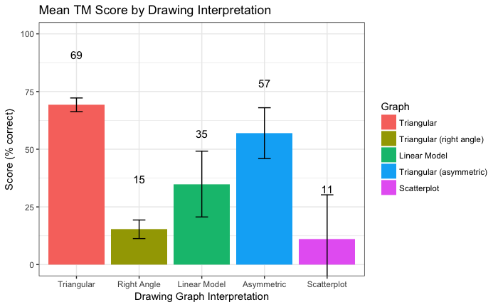

```
Call:
aov(formula = value ~ interpretation, data = t_scores)

Residuals:
    Min      1Q  Median      3Q     Max
-10.387  -1.387   0.613   2.613   8.765

Coefficients:
                Estimate Std. Error t value Pr(>|t|)
(Intercept)       5.6260     0.4527  12.428  < 2e-16 ***
interpretation1   4.7610     0.4834   9.849  < 2e-16 ***
interpretation2  -3.3305     0.5961  -5.588 5.03e-08 ***
interpretation3  -0.3907     0.7708  -0.507    0.613
interpretation4   2.9195     0.7111   4.106 5.16e-05 ***
---
Signif. codes:  0 ‘***’ 0.001 ‘**’ 0.01 ‘*’ 0.05 ‘.’ 0.1 ‘ ’ 1

Residual standard error: 3.32 on 311 degrees of freedom
Multiple R-squared:  0.4505,    Adjusted R-squared:  0.4434
F-statistic: 63.73 on 4 and 311 DF,  p-value: < 2.2e-16

  Tukey multiple comparisons of means
    95% family-wise confidence level

Fit: aov(formula = value ~ interpretation, data = t_scores)

$interpretation
                                                       diff         lwr        upr     p adj
Triangular (right angle)-Triangular              -8.0915020  -9.5906432 -6.5923608 0.0000000
Linear Model-Triangular                          -5.1516624  -7.4415682 -2.8617566 0.0000000
Triangular (asymmetric)-Triangular               -1.8415020  -3.8747133  0.1917094 0.0966309
Scatterplot-Triangular                           -8.7202899 -14.0146189 -3.4259608 0.0000860
Linear Model-Triangular (right angle)             2.9398396   0.3380532  5.5416259 0.0178604
Triangular (asymmetric)-Triangular (right angle)  6.2500000   3.8710144  8.6289856 0.0000000
Scatterplot-Triangular (right angle)             -0.6287879  -6.0652890  4.8077132 0.9977943
Triangular (asymmetric)-Linear Model              3.3101604   0.3680835  6.2522373 0.0186009
Scatterplot-Linear Model                         -3.5686275  -9.2740449  2.1367900 0.4254537
Scatterplot-Triangular (asymmetric)              -6.8787879 -12.4861106 -1.2714652 0.0076050
```

## DISCUSSION

Were there significant differences in learning phase performance?

What was the variance in TM scores?

#### Effect size of scenario X graph interaction

[output not shown]